# Lab 3: Mine Crafting

As with previous labs, be sure to submit only the `lab3.ipynb` and `lab3.html` version of the lab in your github `Lab3` folder. No more, and no less.

## Name: Caden Unger

## Introduction

Imagine you are a scientist for a mining company that operates a vertical mine at the Earth's equator. This is one of the deepest mines on Earth; it's roughly 4 km to the bottom of the shaft. Your boss proposes to measure the vertical depth of the shaft by dropping a 1 kg test mass and accurately measuring the time to hit the bottom.

You will be guided in your investigations below and submit your report in the form of this notebook. Be sure to be quantitative in nature, produce highly polished plots, with appropriate titles, units, etc.

A table of relevant physical constants is below. Good luck!

| Quantity | Value |
| --- | --- |
| Gravitational Constant ($G$) | $6.6743 \times 10^{-11}$ m$^3$/kg/s$^2$ |
| Gravitational Acceleration ($g_o$) | 9.81 m/s$^2$ (approximate) |
| Mass of the Earth ($M_{\oplus}$) | $5.972 \times 10^{24}$ kg |
| Mass of the Moon ($M_{m}$) | $7.35 \times 10^{22}$ kg |
| Radius of the Earth ($R_{\oplus}$) | 6378.1 km |
| Radius of the Moon ($R_{m}$) | 1738.1 km |
| Earth's Rotation Rate at the Equator | $7.272 \times 10^{-5} $ rad/s |

```python
import numpy as np
import matplotlib.pyplot as plt
import pandas as pd
from scipy.integrate import solve_ivp
from scipy.integrate import quad

G = 6.6743e-11
print(G)
g_0 = 9.81
print(g_0)
M_earth = 5.972e24
print(M_earth)
R_earth = 6.3781e6
print(R_earth)
R_moon = 1.7381e6
print(R_moon)
M_moon = 7.35e22
print(M_moon)
Earth_rotation = 7.272e-5
print(Earth_rotation)
```

```
6.6743e-11
9.81
5.972e+24
6378100.0
1738100.0
7.35e+22
7.272e-05
```

## Part 1: The Ideal Case

In this section and the following sections, we calculate the time for the 1 kg test mass to reach the bottom of the mineshaft under a series of increasingly complex assumptions. Remember that a projectile experiencing a constant gravitational force, plus a drag force, obeys the following second order differential equation:

$$ \frac{d^2y}{dt^2} = -g + \alpha \left| \frac{dy}{dt} \right|^{\gamma} \tag{1} $$

where $t$ is time, $y$ is the height, $g$ is the gravitational acceleration, $\alpha$ is the drag coefficient, and $\gamma$ is the speed dependence of the drag. For example, for $\gamma=2$, the drag force grows proportionally to the speed *squared*. **Hint**: pay particular attention to the sign conventions in your implementation! The drag, by definition, should *oppose* the direction of motion.

1. First, make a simple calculation of how long a test mass would take to reach the bottom of the 4km shaft assuming no drag. This is the simple free-fall algebraic expression you know from PHYS 171.
2. Next, reduce (1) into a *system* of coupled first order differential equations by setting the velocity $v = dy/dt$.
3. Numerically solve (1) using `solve_ivp` assuming $\alpha=0$. Plot the position and velocity as a function of time.  
   Draw a horizontal dashed line at the depth of the bottom of the shaft, to make it easy to see. Make the plot look nice, including displaying the position on the left axes, and plotting the velocity on a second right axis, using matplotlib `twinx` capability.  
   In your notebook, label this figure clearly as **Figure 1**.
4. Using the `events` detection capability of `solve_ivp`, calculate the time at which the mass hits the bottom of the shaft in the case of zero drag ($\alpha=0$). Compare this to your analytic calculation and discuss any differences you might see.

```python
#y_t = 0.5 * g *(t^2)
# 8000 = g * t^2
# sqrt(8000/g)
time_no_drag = np.abs(np.sqrt( 8000/ g_0 ))
print(f'Time for test mass with no drag to reach the bottom (calculated): {time_no_drag} Seconds')
```

```
Time for test mass with no drag to reach the bottom (calculated): 28.55686245854129 Seconds
```

$ \frac{dy}{dt} = v $

$\frac{dv}{dt} = -g + \alpha \left| v \right|^{\gamma} $

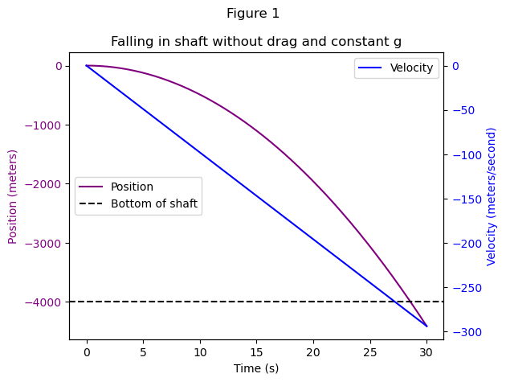

```python
gamma = 0
alpha = 0
def derivatives_1(t, s) :
    y, v = s
    dydt = v
    dvdt = -g_0 + alpha* (np.abs(v) ** gamma)
    return[dydt, dvdt]

t_span = (0, 30)
t_eval = np.linspace(0, 30, 200)
y0 = [0,0]
#help(solve_ivp)
soln_1 = solve_ivp(derivatives_1, t_span, y0, t_eval = t_eval)
#print(soln_2a)

t_1 = soln_1.t
y_1 = soln_1.y[0]
v_1 = soln_1.y[1]

#Fix colors of twin axes
fig1, ax1 = plt.subplots()
ax2 = ax1.twinx()
ax1.plot(t_1, y_1, color = "Purple", label = 'Position')
ax2.plot(t_1, v_1, color = 'b', label = 'Velocity')
ax1.set_title('Falling in shaft without drag and constant g')
ax1.set_xlabel('Time (s)')
ax1.set_ylabel('Position (meters)', color = 'purple')
ax2.set_ylabel('Velocity (meters/second)', color = 'blue')
ax1.axhline(-4000, ls = '--', label = 'Bottom of shaft', color = 'Black')
ax1.tick_params(axis = "y", labelcolor = "purple")
ax2.tick_params(axis = "y", labelcolor = "b")
ax1.legend(loc = 'center left')
ax2.legend()
fig1.suptitle('Figure 1')
fig1.tight_layout()
```

```python
def crash(t, s) :
    return s[0] + 4000

Crash_soln_1 = solve_ivp(derivatives_1, t_span, y0, t_eval = t_eval, events = crash)
print(f'Time for object to reach the bottom (Solve_ivp): {Crash_soln_1.t_events[0][0]} seconds')
print(f'Time for test mass with no drag to reach the bottom (calculated): {time_no_drag} seconds')
print('The two times are almost exactly the same, which is what you would expect. The numbers only diverge at the 15th decimal point, likely due to small rounding errors.')
```

```
Time for object to reach the bottom (Solve_ivp): 28.556862458541275 seconds
Time for test mass with no drag to reach the bottom (calculated): 28.55686245854129 seconds
The two times are almost exactly the same, which is what you would expect. The numbers only diverge at the 15th decimal point, likely due to small rounding errors.
```

## Part 2: Including Drag and a Variable g

In practice, we cannot ignore drag, and we should also not assume that $g$ is a constant. If you approximate that the mass of the Earth is distributed homogenously (which it is not!), then the gravitational constant $g$ will depend on your distance $r$ from the center of the Earth in a simple linear way:

$$ g(r) = g_o \left( \frac{r}{R_{\oplus}} \right) \tag{2} $$

where $g_o$ is the gravity at the surface, and $R_{\oplus}$ is the radius of the Earth.

1. Make a new plot that shows the velocity and position as a function of  
   time assuming $g(y)$. Be careful with coordinate systems! The test mass' position should be at the Earth radius at $t=0$, and falling down. But for plotting purposes, it will be useful to plot the height above the bottom of the shaft.  
   In your notebook, label this figure clearly as **Figure 2**.
2. What effect does incorporating a height-dependent $g$ have on the fall time? Explain.
3. Now, turn on drag, and replot the position and velocity. For most things, $\gamma=2$ is a good assumption. How can you calibrate the value of $\alpha$? Think about what we did in Lecture 15/16, where we assumed a sky-diver's terminal speed was 50 m/s. You should assume the same of the test mass. What affect does including drag have on the fall time?

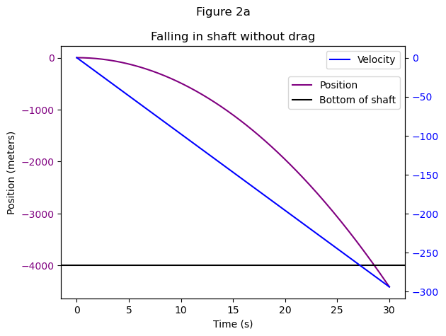

```python
#1
def g(r):
    return g_0 * (r/R_earth)

gamma = 0
alpha = 0
def derivatives_2a(t, s) :
    y, v = s
    dydt = v
    r_object = y + R_earth
    g_y = g(r_object)
    dvdt = -g_y + alpha* (np.abs(v) ** gamma)
    return[dydt, dvdt]

t_span = (0, 30)
t_eval = np.linspace(0, 30, 200)
y0 = [0,0]
#help(solve_ivp)
soln_2a = solve_ivp(derivatives_2a, t_span, y0, t_eval = t_eval)
#print(soln_2a)

t_2a = soln_2a.t
y_2a = soln_2a.y[0]
v_2a = soln_2a.y[1]

#Fix colors of twin axes
fig1, ax1 = plt.subplots()
ax2 = ax1.twinx()
ax1.plot(t_2a, y_2a, color = "purple", label = 'Position')
ax2.plot(t_2a, v_2a, color = 'b', label = 'Velocity')
ax1.set_title('Falling in shaft without drag')
ax1.set_xlabel('Time (s)')
ax1.set_ylabel('Position (meters)')
ax1.axhline(-4000, label = 'Bottom of shaft', color = 'Black')
ax1.tick_params(axis = "y", labelcolor = "purple")
ax2.tick_params(axis = "y", labelcolor = "b")
ax1.legend(loc = 'upper right', bbox_to_anchor=(1, 0.9))
ax2.legend()
fig1.suptitle('Figure 2a')
fig1.tight_layout()
```

```python
#2)

def crash(t, s) :
    return s[0] + 4000

Crash_soln_g0 = solve_ivp(derivatives_1, t_span, y0, t_eval = t_eval, events = crash)
Crash_soln_gy = solve_ivp(derivatives_2a, t_span, y0, t_eval = t_eval, events = crash)
print(f'Time for object to reach the bottom with constant g : {Crash_soln_g0.t_events[0][0]} seconds')
print(f'Time for object to reach the bottom with g(y) :       {Crash_soln_gy.t_events[0][0]} seconds')
print(f'Difference in time : {Crash_soln_g0.t_events[0][0] - Crash_soln_gy.t_events[0][0]} seconds')
print('We see an extremely slight increase in the time that it takes for the object to reach the bottom of the shaft, which makes sense because as the object gets closer to the middle of the earth it accelerates very slightly slower. However, this difference is extremely small because 4000 meters is very small compared to the radius of the earth, so there is no almost no difference in the value of g over just 4000 meters ')
```

[output not shown]

```
Including a drag force has a huge effect on the falling mass, more than doubling the amount of time it takes the mass to reach the bottom of the shaft because it reaches terminal velocity instead of just accelerating indefinitely
```

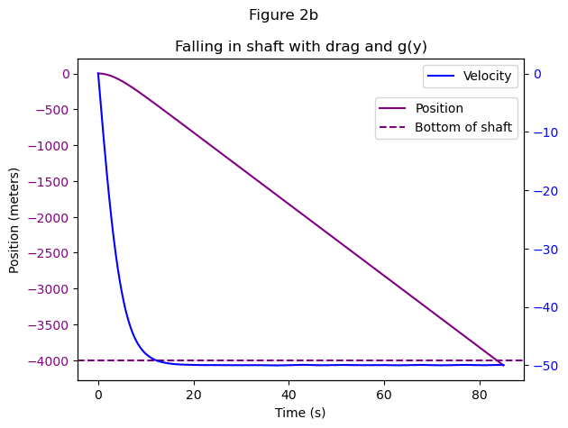

```python
# 0 = -g + drag force     when terminal velocity
#g = a |v|^gamma     For terminal velocity (v = 50)
#g/|v|^gamma  = a
gamma = 2
v_term = 50
calibrated_alpha = g_0 / ( (np.abs(v_term)) ** gamma)
alpha = calibrated_alpha
#print(f'Calibrated alpha value: {calibrated_alpha}')

def derivatives_2b(t, s) :
    y, v = s
    dydt = v
    r_object = y + R_earth
    g_y = g(r_object)
    dvdt = -g_y + alpha* (np.abs(v) ** gamma)
    return[dydt, dvdt]

t_span_2b = (0, 85)
t_eval_2b = np.linspace(0, 85, 1000)
y0 = [0,0]
#help(solve_ivp)
soln_2b = solve_ivp(derivatives_2b, t_span_2b, y0, t_eval = t_eval_2b)
#print(soln_2b)

t_2b = soln_2b.t
y_2b = soln_2b.y[0]
v_2b = soln_2b.y[1]

#Fix colors of twin axes
fig1, ax1 = plt.subplots()
ax2 = ax1.twinx()
ax1.plot(t_2b, y_2b, color = "purple", label = 'Position')
ax2.plot(t_2b, v_2b, color = 'b', label = 'Velocity')
ax1.set_title('Falling in shaft with drag and g(y)')
ax1.set_xlabel('Time (s)')
ax1.set_ylabel('Position (meters)')
ax1.axhline(-4000, label = 'Bottom of shaft', ls = '--', color = 'purple')
ax1.tick_params(axis = "y", labelcolor = "purple")
ax2.tick_params(axis = "y", labelcolor = "b")
ax1.legend(loc = 'upper right',  bbox_to_anchor=(1, 0.9))
ax2.legend()
fig1.suptitle('Figure 2b')
fig1.tight_layout()
print('Including a drag force has a huge effect on the falling mass, more than doubling the amount of time it takes the mass to reach the bottom of the shaft because it reaches terminal velocity instead of just accelerating indefinitely')
```

## Part 3: The Coriolis Force

Since the Earth is rotating, there is a Coriolis force on the test mass as it falls. The force can be quite large. For example, imagine the mine shaft is on the Earth's equator and pointed towards the Earth's center. The equator rotates at about half a kilometer per second. So once the test mass has fallen for some time, it will bump into the wall, unless the shaft is very wide. The Coriolis force $\vec{F_c}$ is:

$$ \vec{F_c} = -2m \, \left( \vec{\Omega} \times \vec{v} \right) \tag{3} $$

where $\vec{\Omega}$ is the Earth's rotation rate for a vector along $\hat{z}$ and $m$ is the mass of the object (1 kg for the test mass in this case). For a mine shaft on the equator, we might pick a right-handed coordinate system with the $\hat{x}$ axis along the East, $\hat{y}$ down into the mine shaft, and $\hat{z}$ along the North. This implies the component of the force are:

\begin{equation} F_{c_x} = + 2m \, \Omega v_y \tag{4} \end{equation} \begin{equation} F_{c_y} = - 2m \, \Omega v_x \tag{5} \end{equation} \begin{equation} F_{c_z} = 0 \tag{6} \end{equation}

1. Extend and update your differential equations of motion to include the Coriolis force. You will need to add a Coriolis acceleration term to your equation for the depth coordinate (remember, $F=ma$), and additionally, start tracking the velocity and position in the transverse direction (``side-to-side'' in the shaft).
2. Plot the transverse position of the object as a function of depth, initially assuming $\alpha=0$. That is, both axes will have units of distance. Plot ``dots" every few seconds so that you can see how the particle moves over time. Note that your depth and transverse axes are likely to have very different length scales. The depth will have a range of 4 km, while the transverse direction is about 5m.  
   In your report, this should be **Figure 3**.
3. If the mine shaft is 5m wide, and you drop the test mass from the center, does the test mass reach the bottom? Or does it bump into the wall first?
4. Now turn drag back on. Does drag make any difference here?

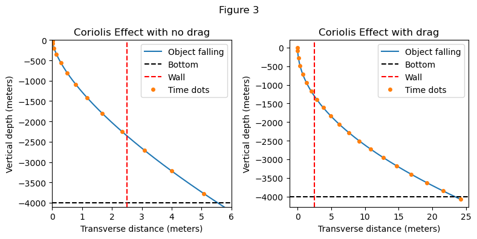

```python
#1 & 2)
m = 1
alpha = 0
gamma = 2
def derivatives_3(t, s) :
    y, v_y, x, v_x = s
    dydt = v_y
    dxdt = v_x
    r_object = y + R_earth
    g_y = g(r_object)
    dvydt = -g_y + alpha* (np.abs(v_y) ** gamma) - (2 * Earth_rotation * v_x)
    dvxdt = -2 * Earth_rotation * v_y #added the negative so it would go to the right

    return[dydt, dvydt, dxdt, dvxdt]

t_span = (0, 30)
t_eval = np.linspace(0, 30, 200)
y0 = [0,0,0,0]
#help(solve_ivp)
soln_3 = solve_ivp(derivatives_3, t_span, y0, t_eval = t_eval)
#print(soln_3)

x_nd = soln_3.y[2]
y_nd = soln_3.y[0]

fig3, (ax3, ax4) = plt.subplots(1,2, figsize = (8,4))
ax3.plot(x_nd, y_nd, label = 'Object falling')
ax3.set_xlim(0,6)
ax3.set_ylim(-4100, 0)
ax3.axhline(-4000, label = 'Bottom', linestyle = '--', color = 'black')
ax3.axvline(2.5, label = 'Wall', linestyle = '--', color = 'r')

mask = np.linspace(0,199,15, dtype = int)
time_dots = soln_3.t[mask]
xposition_dots = x_nd[mask]
yposition_dots = y_nd[mask]
ax3.plot(xposition_dots, yposition_dots, 'o', ms = 4, label = 'Time dots')

ax3.set_xlabel('Transverse distance (meters)')
ax3.set_ylabel('Vertical depth (meters)')
ax3.set_title('Coriolis Effect with no drag')
ax3.legend()

#4)
m = 1
alpha = calibrated_alpha
gamma = 2
def derivatives_3d(t, s) :
    y, v_y, x, v_x = s
    dydt = v_y
    dxdt = v_x
    r_object = y + R_earth
    g_y = g(r_object)
    dvydt = -g_y + alpha* (np.abs(v_y) ** gamma) - (2 * Earth_rotation * v_x)
    dvxdt = -2 * Earth_rotation * v_y #added the negative so it would go to the right

    return[dydt, dvydt, dxdt, dvxdt]

t_span = (0, 85)
t_eval = np.linspace(0, 85, 400)
y0 = [0,0,0,0]
#help(solve_ivp)
soln_3d = solve_ivp(derivatives_3d, t_span, y0, t_eval = t_eval)
#print(soln_3d)

x_d = soln_3d.y[2]
y_d = soln_3d.y[0]

ax4.plot(x_d, y_d, label = 'Object falling')
ax4.axhline(-4000, label = 'Bottom', linestyle = '--', color = 'black')
ax4.axvline(2.5, label = 'Wall', linestyle = '--', color = 'r')

mask_d = np.linspace(0,399,20, dtype = int)
time_dots_d = soln_3d.t[mask_d]
xposition_dots_d = x_d[mask_d]
yposition_dots_d = y_d[mask_d]

ax4.plot(xposition_dots_d, yposition_dots_d, 'o', ms = 4, label = 'Time dots')

ax4.set_xlabel('Transverse distance (meters)')
ax4.set_ylabel('Vertical depth (meters)')
ax4.set_title('Coriolis Effect with drag')
ax4.legend()
fig3.suptitle('Figure 3')
fig3.tight_layout()
```

We can see that even without drag the mass clearly contacts the wall before hitting the bottom of the shaft. It travels the 2.5 meters horizontally to contact the side of the wall in the time it falls about 2500 meters so the object clearly hits the wall before the bottom of the shaft. When drag is added, we can see that the object hits the side wall at an even higher altitude which makes physical sense because there is minimal drag force on the horizontal mouvement of the ball as it it's horizontal velocity is extremely slow, so the drag mostly just slows down the vertical movement and therefore the object contacts the wall higher up.

## Part 4: An infinitely deep mine

Now, let us consider the theoretical case of an infinitely deep mine -- that is, a tunnel which traverses the full diameter of the Earth. For convenience, imagine the tunnel goes from pole-to-pole, such that $\vec{\Omega} \times \vec{v} = 0$, and the Coriolis force can be neglected, as well as the drag force.

Additionally, continue assuming a constant density Earth.

1. Again, plot the depth and velocity as a function of time. (Be careful with the meaning of $y$, as the particle can theoretically traverse fully through to the other side of the Earth.) Comment on what you see in the graph.  
   In your notebook, label this figure clearly as **Figure 4**.
2. How long will it take for the object to reach the other side? At what time does the object reach the center of the Earth, and at what speed?
3. How does this ``crossing-time" compare to the orbital period, where you assume the object is on a circular orbit, in centripetal balance with the attractive force of the gravity. \begin{equation} \frac{v^2}{R} = \frac{GM}{R^2} \tag{7} \end{equation} gives the orbital speed $v$ for a given Earth radius $R$ and Earth mass $M$.

```
Time for object to reach the center of the earth : 1266.46 seconds
Time for object to reach the other side : 2532.92 seconds
Velocity when object reaches the middle: 7909.74 meters/second
Velocity of the object in orbit: 7905.28 meters/second
```

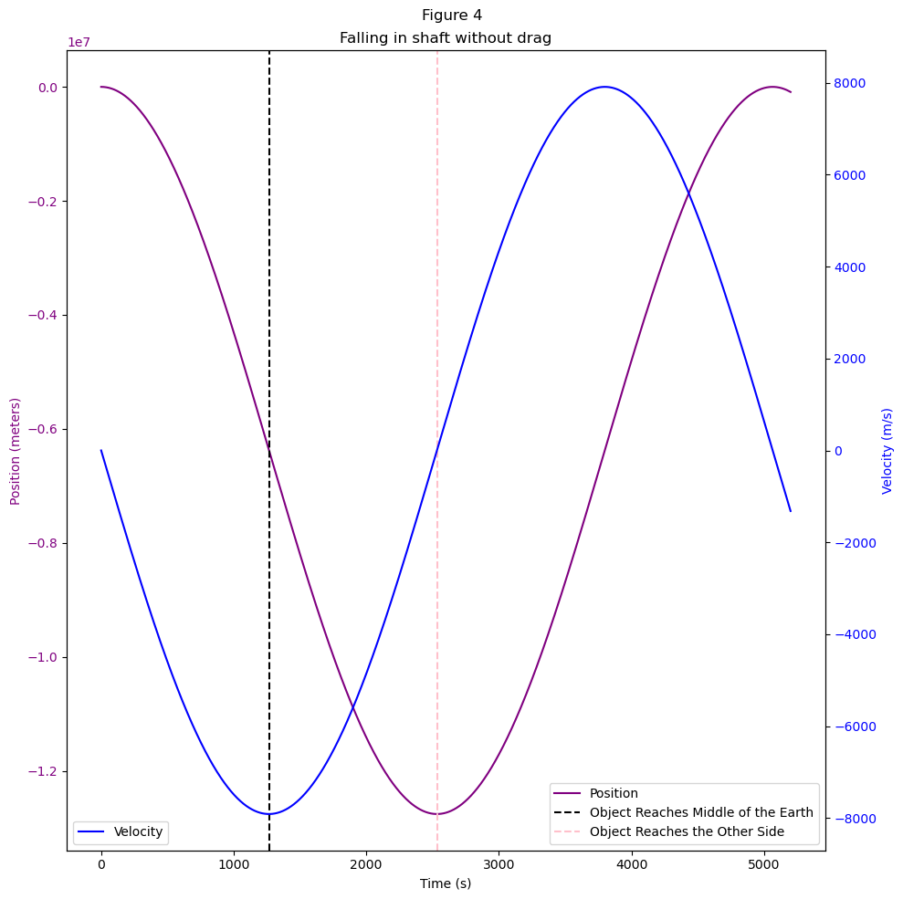

```python
#4
def g(r):
    return g_0 * (r/R_earth)

gamma = 0
alpha = 0
def derivatives_4(t, s) :
    y, v = s
    dydt = v
    r_object = y + R_earth
    g_y = g(r_object)
    dvdt = -g_y + alpha* (np.abs(v) ** gamma)
    return[dydt, dvdt]

t_span = (0, 5200)
t_eval = np.linspace(0, 5200, 10000)
y0 = [0,0]
#help(solve_ivp)
soln_4 = solve_ivp(derivatives_4, t_span, y0, t_eval = t_eval)
#print(soln_4)

t_4 = soln_4.t
y_4 = soln_4.y[0]
#depth = R_earth - np.abs(R_earth + y_4)
v_4 = soln_4.y[1]

#Fix colors of twin axes
fig4, ax4 = plt.subplots(figsize = (10,10))
ax5 = ax4.twinx()
ax4.plot(t_4, y_4, color = "purple", label = 'Position')
ax5.plot(t_4, v_4, color = 'b', label = 'Velocity')
ax4.set_title('Falling in shaft without drag')
ax4.set_xlabel('Time (s)')
ax4.set_ylabel('Position (meters)', color = 'purple')
ax5.set_ylabel('Velocity (m/s)', color = 'blue')
ax4.tick_params(axis = "y", labelcolor = "purple")
ax5.tick_params(axis = "y", labelcolor = "b")
ax5.legend(loc = 'lower left')
fig4.suptitle('Figure 4')

def middle(t, s) :
    return s[0] + R_earth

Middle = solve_ivp(derivatives_4, t_span, y0, t_eval = t_eval, events = middle)
Time_to_middle = Middle.t_events[0][0]
print(f'Time for object to reach the center of the earth : {Time_to_middle:.2f} seconds')
#print(np.min(v_4))
#print(R_earth)
#print(Middle)
ax4.axvline(Time_to_middle, label = 'Object Reaches Middle of the Earth', ls = '--', color = 'black')

def Through(t, s) :
    return s[0] + 2 * R_earth

Time_through = 2 * Time_to_middle
print(f'Time for object to reach the other side : {Time_through:.2f} seconds')
ax4.axvline(Time_through, label = 'Object Reaches the Other Side', ls = '--', color = 'pink')


ax4.legend(loc = 'lower right')
fig4.tight_layout()

v_at_mid = Middle.y_events[0][1][1]
print(f'Velocity when object reaches the middle: {v_at_mid:.2f} meters/second')

v_orbital = np.sqrt( (G * M_earth) / R_earth)
#angular v = v_orbirtal/R_earth
print(f'Velocity of the object in orbit: {v_orbital:.2f} meters/second')
```

```python
v_orbital = np.sqrt( (G * M_earth) / R_earth)
angular_v = v_orbital/R_earth
Period =  2 * np.pi / angular_v
print(f'Velocity of the object in orbit: {v_orbital:.2f} meters/second')
print(f'Orbital Period: {Period:.2f} seconds')
#print(f'Time for object to reach the center of the earth : {Time_to_middle:.2f} seconds')
print(f'Time for object to complete a period through and back : {4 * Time_to_middle:.2f} seconds')
```

```
Velocity of the object in orbit: 7905.28 meters/second
Orbital Period: 5069.37 seconds
Time for object to complete a period through and back : 5065.84 seconds
```

$\frac{v^2}{R} = \frac{GM}{R^2} $

$ v^2 = \frac{GM}{R} $

$ v = \sqrt{\frac{GM}{R} } $

$ \omega = \frac{v}{R} $

$ T = \frac{2 \pi}{\omega} $

$ T = \frac{2 \pi R}{{\sqrt{\frac{GM}{R} }}} $

Value is almost exactly the same as the 4 times as the time of the object to cross the middle of the earth, ie one period of accross the earth and back is equal to one orbital period around the earth.

## Part 5: A non-uniform Earth

Finally, let us consider the case of a non-uniform Earth, and continue assuming we have no drag. We know from geology that the density increases towards the center. It rises from about 2-3 g/cm$^3$ near the surface, to more like 13 near the center. A simple model for the density $\rho$ as a function of distance from the center of the Earth $r$ is:

$$ \rho(r) = \rho_n \left( 1 - \frac{r^2}{R_{\oplus}^2} \right)^n \tag{8} $$

where $n$ is some exponent, and $\rho_n$ is a normalizing constant. The case of $n=0$ is the constant density Earth, while $n=2$ is closer to the real value. Note that the total mass of the Earth, $M$, must be conserved. Since the mass is the volume integral over the density:

\begin{equation} M = \int_V \rho(r) dV = \int_0^{2\pi} \int_0^{\pi} \int_0^{R_{\oplus}} \rho(r) r^2 \sin \phi \, dr \, d\phi \,d\theta = 4 \pi \int_0^{R_{\oplus}} \rho(r) r^2 \, dr \tag{9} \end{equation}

you will need to recompute the density constant $\rho_n$ for each case of $n>0$, You can use the `quad` integrator for this. Note that the analytic solution is straightforward to do by hand for $n=0$, and still manageable for $n=1,2$. You might consider doing that integral to make sure your method is right, and then you can be confident for $n>0$.

1. Plot the normalized density profile (that is, set $\rho_n=1$) as a function of radius for $n=0, 1, 2, 9$.  
   Put them all on the same plot, with a clear legend.  
   In your notebook, label this figure clearly as **Figure 5**.
2. Now, plot the force profile as a function of radius for $n=0, 1, 2, 9$.  
   This step will show you if your normalization factor $\rho_n$ is correct, because the surface force must be the same for all $n$.  
   In your notebook, label this figure clearly as **Figure 6**.
3. Then, plot the position and velocity as a function of time for $n=0, 1, 2, 9$ as you did in Figure 1/2.  
   In your notebook, label this figure clearly as **Figure 7**.
4. For $n=0, 1, 2, 9$, compute the time to reach the center, and the speed achieved there.

### Part 5, Section A (Density)

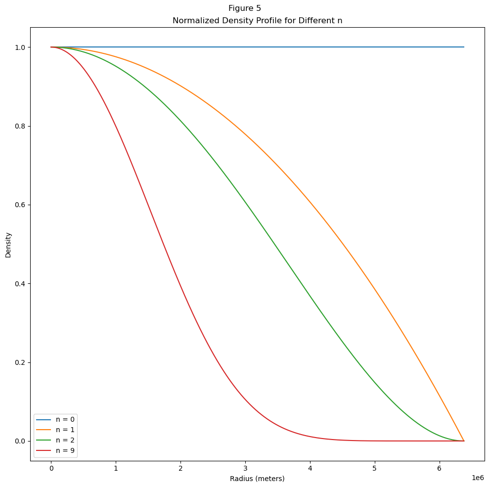

```python
def p_0(r):
    return r**0

def p_1(r):
    return (1 - (r**2)/(R_earth**2))

def p_2(r):
    return (1 - (r**2)/(R_earth**2))**2

def p_9(r):
    return (1 - (r**2)/(R_earth**2))**9

rr = np.linspace(0, R_earth, 1000)
p0 = p_0(rr)
p1 = p_1(rr)
p2 = p_2(rr)
p9 = p_9(rr)

fig, ax = plt.subplots(figsize = (10,10))

ax.plot(rr, p0, label = 'n = 0' )
ax.plot(rr, p1, label = 'n = 1' )
ax.plot(rr, p2, label = 'n = 2' )
ax.plot(rr, p9, label = 'n = 9' )
ax.legend()
ax.set_xlabel('Radius (meters)')
ax.set_ylabel('Density')
ax.set_title('Normalized Density Profile for Different n')
fig.suptitle('Figure 5')
ax.legend()
fig.tight_layout()
```

### Part 5, Section B (Forces)

```
n=0 : rho_0 = 5494.867, Total Mass = 5.9720e+24
n=1 : rho_1 = 13737.169, Total Mass = 5.9720e+24
n=2 : rho_2 = 24040.045, Total Mass = 5.9720e+24
n=9 : rho_9 = 135545.121, Total Mass = 5.9720e+24
```

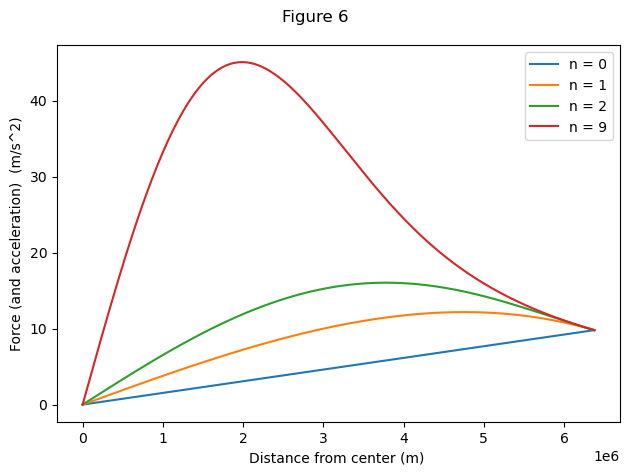

```python
#help(quad)
def density(r, n):
    return  4 * np.pi * ((1 - (r**2) / (R_earth**2))**n ) * (r**2)

def rho_density(r, n, rho_n ) :
    return 4 * np.pi * (rho_n * ( (1 - (r**2) / (R_earth**2))**n )) * (r**2)
#n = 0
#integral, error = quad(density, 0, R_earth, args = (n,))
#print(integral)
#rho_n = M_earth / integral
#print(rho_n)

for n in [0,1,2,9] :
    integral, error = quad(density, 0, R_earth, args = (n,))
    rho_n = M_earth/integral
    integral2, error2 = quad(rho_density, 0, R_earth, args = (n,rho_n)) #confirming total mass the same
    print(f'n={n} : rho_{n} = {rho_n:.3f}, Total Mass = {integral2:.4e}')

def F_r(r, n, rho_n) :
    integral3, error3 = quad(rho_density, 0, r, args = (n, rho_n) )
    return (integral3 * G * m )/ (r**2)


rr = np.linspace(0.00001,R_earth, 500)
fig6, ax6 = plt.subplots()

for n in [0,1,2,9] :
    integral, error = quad(density, 0, R_earth, args = (n,))
    rho_n = M_earth/integral
    g_vals = []
    for r in rr:
        g = F_r(r, n, rho_n)
        g_vals.append(g)
    ax6.plot(rr, g_vals, label=f'n = {n}')

ax6.legend()
ax6.set_ylabel('Force (and acceleration)  (m/s^2)' )
ax6.set_xlabel('Distance from center (m) ')
fig6.suptitle('Figure 6')
fig6.tight_layout()
```

### Part 5, Section C (Equations of Motion)

```
n=0 : Time to Middle = 1267.23 seconds, Velocity at Middle = 7904.96 meters/second
n=1 : Time to Middle = 1096.51 seconds, Velocity at Middle = 10471.81 meters/second
n=2 : Time to Middle = 1035.15 seconds, Velocity at Middle = 12205.31 meters/second
n=9 : Time to Middle = 943.84 seconds, Velocity at Middle = 18409.91 meters/second
```

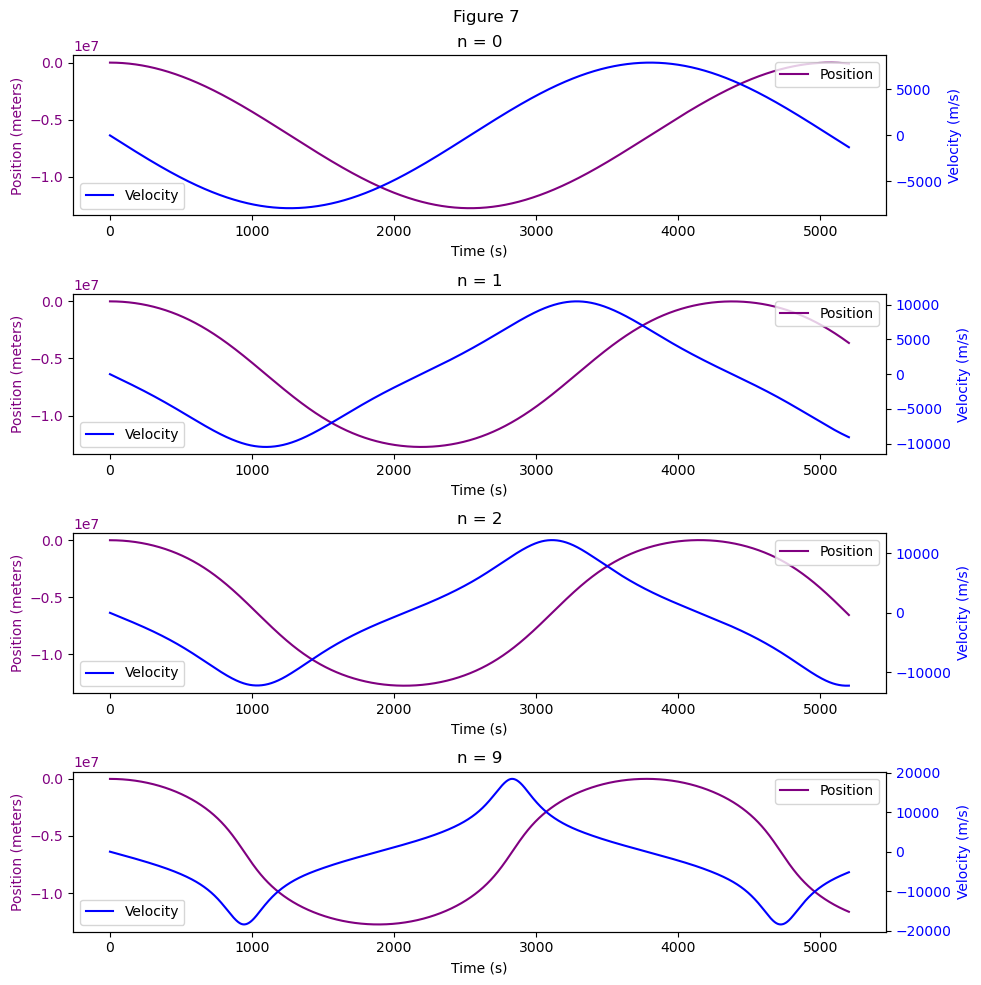

```python
fig7, axes = plt.subplots(4,1, figsize = (10,10))

gamma = 0
alpha = 0
def derivatives_5(t, s, n, rho_n):
    y, v = s
    dydt = v
    r_object = y + R_earth
    g_y = F_r(r_object, n, rho_n)
    dvdt = -g_y + alpha* (np.abs(v) ** gamma)
    return [dydt, dvdt]

def middle(t, s, n, rho_n) :
    return s[0] + R_earth

i = 0
for n in [0, 1, 2, 9]:
    integral, error = quad(density, 0, R_earth, args=(n,))
    rho_n = M_earth / integral
    soln_5 = solve_ivp(derivatives_5, t_span, y0, t_eval=t_eval, args=(n, rho_n))
    axes[i].plot(soln_5.t, soln_5.y[0], label='Position', color = 'purple')
    axes[i].set_title(f'n = {n}')
    axes[i].set_xlabel('Time (s)')
    ax_v = axes[i].twinx()
    ax_v.plot(soln_5.t, soln_5.y[1], label='Velocity', color = "b")
    axes[i].tick_params(axis = "y", labelcolor = "purple")
    ax_v.tick_params(axis = "y", labelcolor = "b")
    Middle = solve_ivp(derivatives_5, t_span, y0, t_eval = t_eval, events = middle, args=(n, rho_n) )
    Time_to_middle = Middle.t_events[0][0]
    #print(np.min(v_4))
    #print(R_earth)
    #print(Middle)
    v_at_mid = Middle.y_events[0][1][1]
    print(f'n={n} : Time to Middle = {Time_to_middle:.2f} seconds, Velocity at Middle = {v_at_mid:.2f} meters/second')
    axes[i].legend(loc = 'upper right')
    ax_v.legend(loc = 'lower left')
    axes[i].set_ylabel('Position (meters)', color = 'purple')
    ax_v.set_ylabel('Velocity (m/s)', color = 'blue')
    i = i + 1

fig7.suptitle('Figure 7')
fig7.tight_layout()
```

## Part 6: A Lunar Mine Shaft

Finally, with all of the framework in place, consider the case where the the mine shaft is instead dug on the moon.

1. Compute the travel time to the center of the moon in case we dig a pole-to-pole mine shaft, so that we can again avoid the Coriolis force, though on the moon this force is very small. No drag force either, which is actually realistic for the moon!
2. What is the density (if you asssume a constant density) of the moon compared to that of earth?
3. How does the fall/orbit time depend on density? See if you can discover a relationship between the density and the fall time. You should think beyond strictly linear relationships.

This problem can actually be done on paper, and then you can compare the answer with that for the homogenous earth you did in Part 4.

```
Time for object to reach the center of the moon : 1624.93 seconds
```

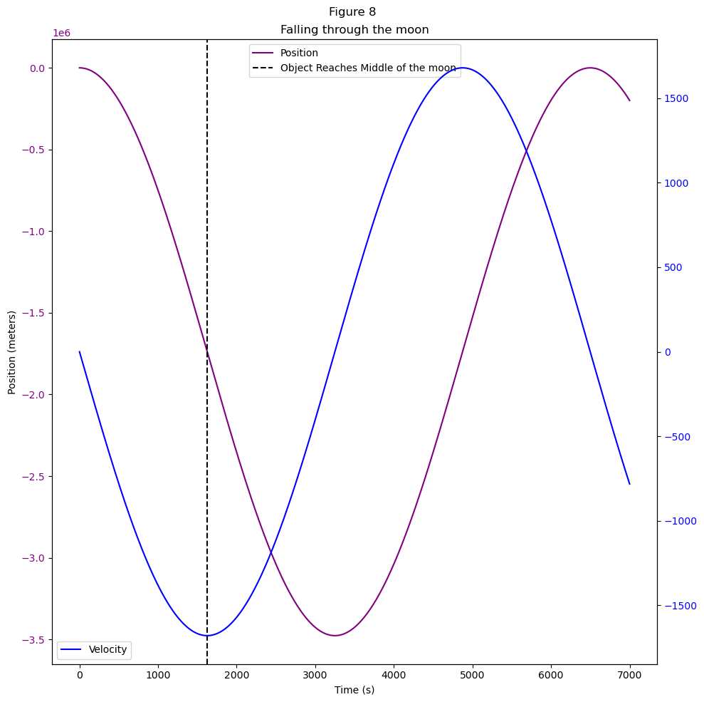

```python
#F = GMm/r^r
g0_moon = (G * M_moon) / (R_moon**2)
def g_moon(r):
    return  g0_moon * (r/R_moon)

gamma = 0
alpha = 0
def derivatives_5(t, s) :
    y, v = s
    dydt = v
    r_object = y + R_moon
    g_y = g_moon(r_object)
    dvdt = -g_y + alpha* (np.abs(v) ** gamma)
    return[dydt, dvdt]

t_span = (0, 7000)
t_eval = np.linspace(0, 7000, 20000)
y0 = [0,0]
#help(solve_ivp)
soln_4 = solve_ivp(derivatives_5, t_span, y0, t_eval = t_eval)
#print(soln_4)

t_4 = soln_4.t
y_4 = soln_4.y[0]
#depth = R_moon - np.abs(R_moon + y_4)
v_4 = soln_4.y[1]

#Fix colors of twin axes
fig4, ax4 = plt.subplots(figsize = (10,10))
ax5 = ax4.twinx()
ax4.plot(t_4, y_4, color = "purple", label = 'Position')
ax5.plot(t_4, v_4, color = 'b', label = 'Velocity')
ax4.set_title('Falling through the moon')
ax4.set_xlabel('Time (s)')
ax4.set_ylabel('Position (meters)')
ax4.tick_params(axis = "y", labelcolor = "purple")
ax5.tick_params(axis = "y", labelcolor = "b")
ax5.legend(loc = 'lower left')
ax4.legend(loc = 'upper center')
fig4.suptitle('Figure 8')

def middle(t, s) :
    return s[0] + R_moon

Middle = solve_ivp(derivatives_5, t_span, y0, t_eval = t_eval, events = middle)
#print(Middle)
Moon_time_to_middle = Middle.t_events[0][0]
print(f'Time for object to reach the center of the moon : {Moon_time_to_middle:.2f} seconds')
#print(np.min(v_4))
#print(R_moon)
#print(Middle)
ax4.axvline(Moon_time_to_middle, label = 'Object Reaches Middle of the moon', ls = '--', color = 'black')

ax4.legend(loc = 'upper center')
fig4.suptitle('Figure 8')
fig4.tight_layout()
```

```python
#Density = Mass/Volume
V_moon = (4/3) * np.pi * (R_moon **3)
Rho_moon = M_moon/ V_moon
V_earth = (4/3) * np.pi * (R_earth **3)
Rho_earth = M_earth/ V_earth
print(f' Density of the Moon: {Rho_moon:.2f}')
print(f' Density of the Earth: {Rho_earth:.2f}')
```

```
 Density of the Moon: 3341.75
 Density of the Earth: 5494.87
```

$ T = \frac{2 \pi R}{{\sqrt{\frac{GM}{R} }}} $

$T = 2\pi\sqrt{\frac{R^3}{GM}}$

Crossing time $ = \frac{\pi}{2} \sqrt{\frac{R^3}{GM}}$

Density $ = \rho = \frac{3M}{4\pi R^3}$

$\frac{R^3}{M} = \frac{3}{4\pi \rho} $ so crossing time $= \frac{\pi}{2} \sqrt{\frac{3}{ 4\pi G \rho}}$

Crossing time is inversely proportional to the square root of density

## Part 7: Fourier Transforming Orbits

Take the solutions for n=0 and n=9 of the orbits in Part 5 (the inhomogeneous earth) and Fourier Transform them, to see what frequencies (*1/periods*) are dominant in the power spectra. Comment on what you see.

**Hint:** you could take the orbit from the previous integration in Part 5c, but it is useful to increase the integration time and sampling to get more meaningful smooth enough curves. We discussed this in class.

For an example of a spectral analysis of galactic orbits see https://articles.adsabs.harvard.edu/pdf/1982ApJ...252..308B

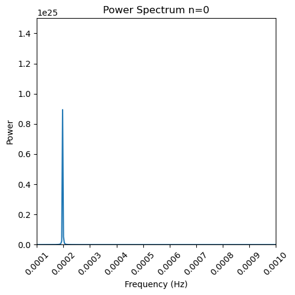

```python
fig8, ax8 = plt.subplots(1,1, figsize = (5,5))

n = 0
gamma = 0
alpha = 0
def derivatives_7(t, s, n, rho_n):
    y, v = s
    dydt = v
    r_object = y + R_earth
    g_y = F_r(r_object, n, rho_n)
    dvdt = -g_y + alpha* (np.abs(v) ** gamma)
    return [dydt, dvdt]

t_span_ft = (0,300000)
t_eval_ft = np.linspace(0,300000, 1000000)
y0 = [0, 0]


integral, error = quad(density, 0, R_earth, args=(n,))
rho_n = M_earth / integral
soln_5 = solve_ivp(derivatives_7, t_span_ft, y0, t_eval=t_eval_ft, args=(n, rho_n))
y_n0_ft = soln_5.y[0]




N = len(y_n0_ft)
F = np.fft.rfft(y_n0_ft)
fs = 1000000/300000
fff = np.fft.rfftfreq(N, d=1/fs)
ax8.plot(fff, np.abs(F)**2)
ax8.set_xlim(0.0001, 0.001)
ax8.set_ylim(0,1.5e25)
ax8.set_xlabel('Frequency (Hz)')
ax8.set_ylabel('Power')
ax8.set_title('Power Spectrum n=0')
ax8.tick_params(axis='x', labelrotation=45)
fig8.tight_layout()
```

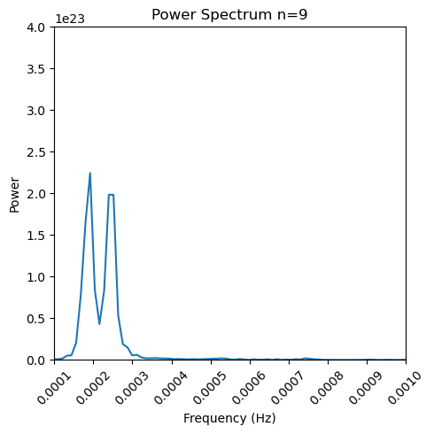

```python
fig8, ax8 = plt.subplots(1,1, figsize = (5,5))

def F_r(r, n, rho_n) :
    if r == 0 :
        return 0
    integral3, error3 = quad(rho_density, 0, r, args = (n, rho_n) )
    return (integral3 * G * m )/ (r**2)


n = 9
gamma = 0
alpha = 0
def derivatives_7(t, s, n, rho_n):
    y, v = s
    dydt = v
    r_object = y + R_earth
    g_y = F_r(r_object, n, rho_n)
    dvdt = -g_y + alpha* (np.abs(v) ** gamma)
    return [dydt, dvdt]

t_span_ft = (0,300000)
t_eval_ft = np.linspace(0,300000, 1000000)
y0 = [0, 0]


integral, error = quad(density, 0, R_earth, args=(n,))
rho_n = M_earth / integral
soln_5 = solve_ivp(derivatives_7, t_span_ft, y0, t_eval=t_eval_ft, args=(n, rho_n))
y_n0_ft = soln_5.y[0]


N = len(y_n0_ft)
F = np.fft.rfft(y_n0_ft)
fs = 1000000/300000
fff = np.fft.rfftfreq(N, d=1/fs)
ax8.plot(fff, np.abs(F)**2)
ax8.set_xlim(0.0001, 0.001)
ax8.set_ylim(0,4e23)
ax8.set_xlabel('Frequency (Hz)')
ax8.set_ylabel('Power')
ax8.set_title('Power Spectrum n=9')
ax8.set_ylim(0,4e23)
ax8.tick_params(axis='x', labelrotation=45)
fig8.tight_layout()
```